# Final_EDA

Leo Huynh

2025-09-27

```r
knitr::opts_chunk$set(echo = TRUE)
```

```r
data_raw <-
  read.table("/Users/leoc.wong/Library/CloudStorage/GoogleDrive-qlhuynh@umich.edu/My Drive/Fall 2025/Stats 551 - Yixin Wang/HW/statlog+german+credit+data/german.data")
# data_2 <- read.table("/Users/leoc.wong/Library/CloudStorage/GoogleDrive-qlhuynh@umich.edu/My Drive/Fall 2025/Stats 551 - Yixin Wang/HW/statlog+german+credit+data/german.data-numeric")
```

```r
# Transform the categorical into factors
# Change column names into appropriate names

# Categorical into Factor
data <- data_raw |> lapply(function(x)
  if (class(x) == "character") {
    return (factor(x))
  }
  else {
    return (x)
  }
  ) |> data.frame()


# Columns names
colnames(data) <- c("check_acc_status", "Duration", "Cred_hist", "Purpose", "Cred_amount",
                      "Savings_bonds", "Present_employment_since", "Installment_rate_%_income",
                      "Personal_status_sex", "Other_debtors_guarantors", "Present_res_since",
                      "Property", "Age", "Other_installment_plans", "Housing", "Num_existing_creds",
                      "Job", "Number_dependence", "Telephone", "Foreign_worker", "Target")

data$Target <- factor(data$Target)
```

# Data Summary

After glancing at some data summary, here are some of the noticeable information we found from a preliminary EDA of the data:

We have 1000 data instances, which is quite substantial. Out of 21 variables, we only have seven numerical variables. However, some variables have only a few unique values, raising the question of whether or not they are useful in our analysis.

The main use of the data is to classify/predict customers who are/should be seen as good or bad credit risk. Good means low risk, and bad means high risk. The classification variable is named “Target”.

### Single Variable Summary

We first summarizes some more prominent features in singular variables:

We first notice the majority of respondents in the data are foreign workers:

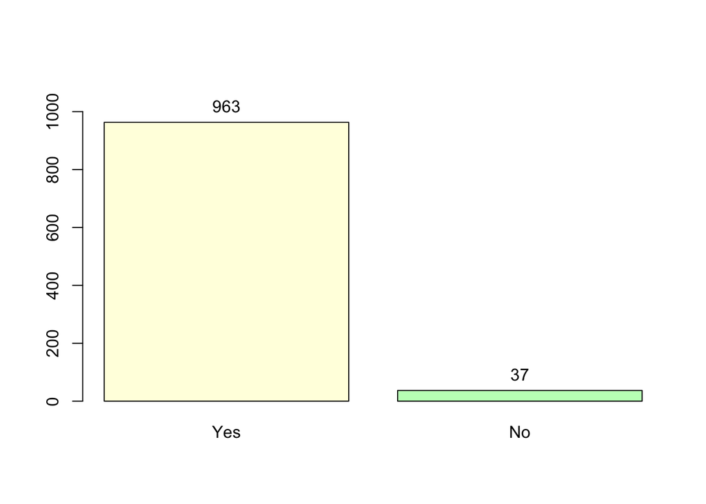

```r
counts <- summary(data$Foreign_worker)
bp <- barplot(counts, col = c("lightyellow", "darkseagreen1"), ylim = c(0, 1100), names.arg = c("Yes", "No"))
# Add text labels on top of bars
text(x = bp, y = counts, labels = counts, pos = 3)
```

```r
rm(bp, counts)
```

For the Target variable classifying people as having good or bad credit risks, we see that there’s a slight imbalance of class.

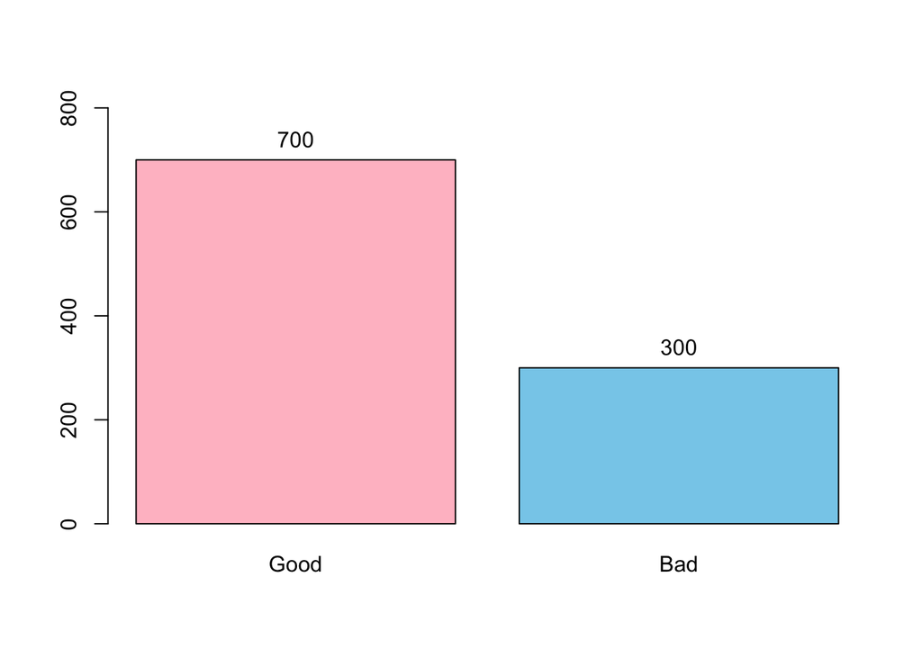

```r
counts <- summary(data$Target)
bp <- barplot(counts, col = c("pink", "skyblue"), ylim = c(0, 800), names.arg = c("Good", "Bad"))
# Add text labels on top of bars
text(x = bp, y = counts, labels = counts, pos = 3)
```

```r
rm(bp, counts)
```

The number of respondents in each category are both relatively decent so that is not a concern, but both numbers being so rounded (700 and 300) raises slight suspicion in sampling bias.

We look at the distributions of three numerical quantities. Notice that credit amount is measured in DM - Deutsche Mark, West Germany’s and Germany’s official currency from 1948 to 1990, and 1990 to 2002, respectively.

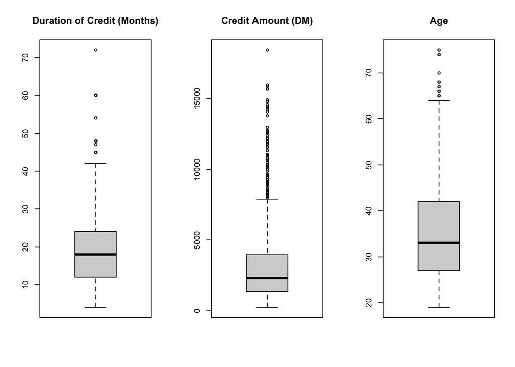

```r
par(mfrow = c(1, 3))
boxplot(data$Duration, main = "Duration of Credit (Months)")
boxplot(data$Cred_amount, main = "Credit Amount (DM)")
boxplot(data$Age, main = "Age")
```

Additionally, most workers are skilled or highly qualified:

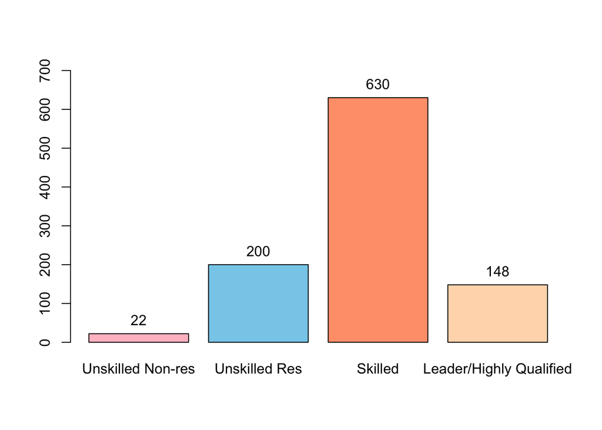

```r
counts <- summary(data$Job)
bp <- barplot(counts, col = c("pink", "skyblue", "#FFA07A", "#FFDAB9"), ylim = c(0, 700), names.arg = c("Unskilled Non-res", "Unskilled Res", "Skilled", "Leader/Highly Qualified"))
# Add text labels on top of bars
text(x = bp, y = counts, labels = counts, pos = 3)
```

```r
rm(bp, counts)
```

```r
# function to get division by column sum
col_div <- function(matrixx) {
   matrixx <- sweep(matrixx, 2, colSums(matrixx), FUN = "/")
   return (round(matrixx, digits = 3))
}
```

### Joint Variable Summary

We observe some interesting findings in the next graph:

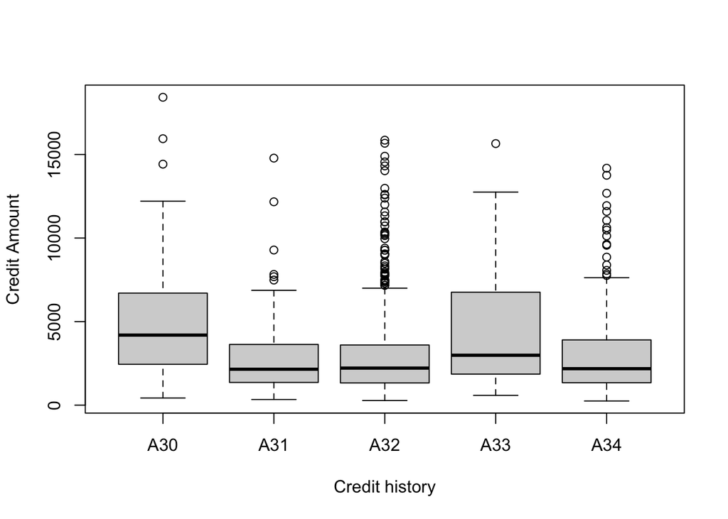

```r
boxplot(data$Cred_amount ~ data$Cred_hist, ylab = "Credit Amount", xlab = "Credit history")
```

Group 0 and 3 generally has higher credit amount than other groups. It makes sense for group 0, being the group with no credits taken/all credits paid back duly, but not for group 3 - delay in paying off in the past. After a few searches, the insight might be clear from this plot:

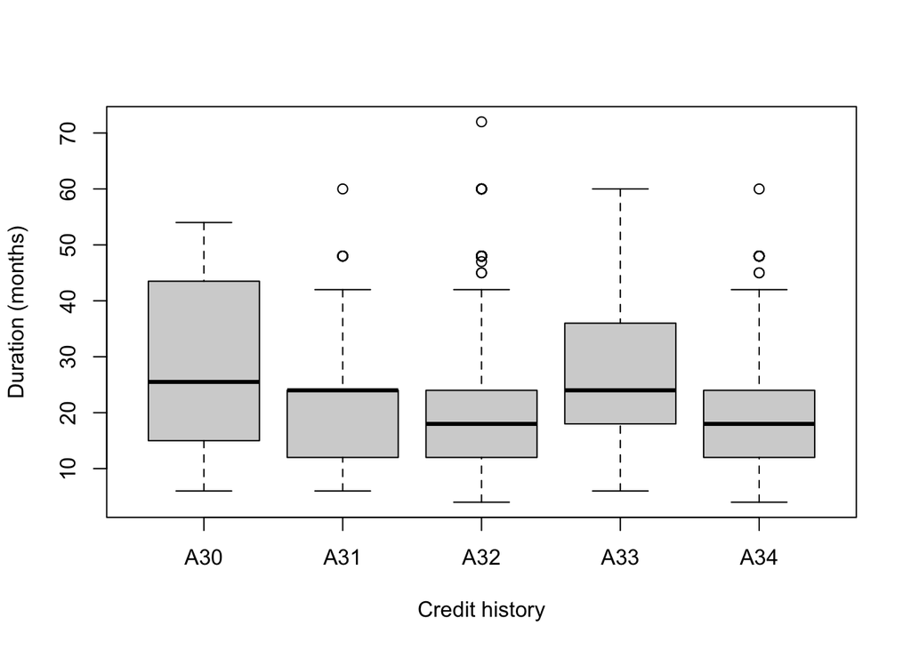

```r
boxplot(data$Duration ~ data$Cred_hist, xlab = "Credit history", ylab = "Duration (months)")
```

We see that group 3 and 0 both generally has the longest duration of credit lines. This gives us two information: (1) group 0 would probably be classified as being very good credit risk, having long duration of accounts and all credits are paid duly, and (2) that group 3 probably has higher credit amounts since they have had the accounts for longer, and thus make them more likely to have had delayed payments in the past.

However, one interesting finding that our EDA hasn’t been able to explain is shown in the below graph. To reiterate, group 0 is the group with no credits taken/ all credits paid back duly, group 1 and 2 has their credits paid back duly, group 3 has had delayed payments in the past, and group 4 is the group with critical account/ other credits existing (not at this bank).

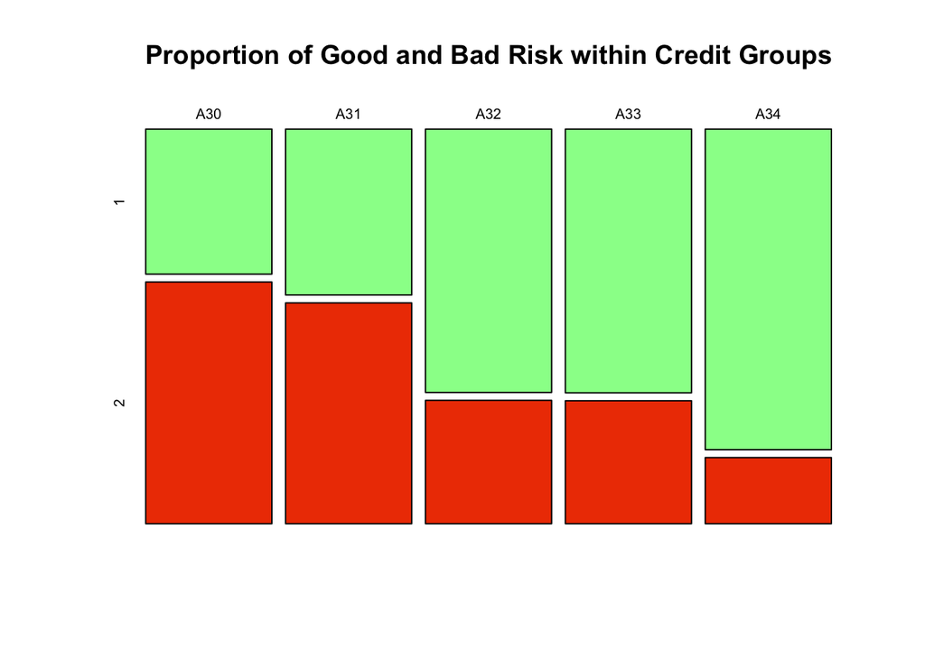

```r
plot(t(col_div(table(data$Target, data$Cred_hist))), col = c("palegreen", "orangered2"),
     main = "Proportion of Good and Bad Risk within Credit Groups")
```

Intuitively, we expect that group 0, 1, and 2 to be more classified as good credit risks, group 3 and 4 most classified as bad risks. We see the complete opposite trend here. We have done substantial checking to make sure our data was handled correctly, cross-checked with many methods, and even manually checking the data, just to discovered the same pattern.

We have gauge at the association between credit history and many other variables, but none seem to have significant association to possibly confound this finding. We suspect there is either: (A) a qualitative reasoning behind the bank classify group 3, 4 more as good risk and the other as bad risks, or (B) there is at least one strong confounding variable that cannot be observed in lower dimensional visualizations/tables.

We observed an interesting pattern for the variable “Checking account status” as well. For this group, group 1 has < 0 DM, group 2 has between 0 and 200 DM, group 3 > 200 DM or have salary assignments for at least 1 year, group 4 does not have a checking account.

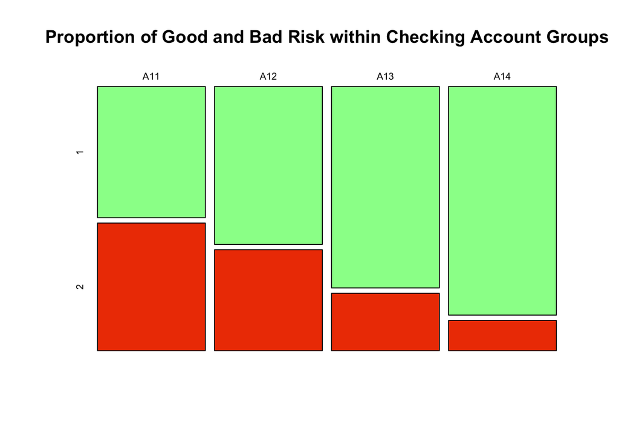

```r
plot(t(col_div(table(data$Target, data$check_acc_status))), col = c("palegreen", "orangered2"),
     main = "Proportion of Good and Bad Risk within Checking Account Groups")
```

We see that there’s an increasing trend from group 1 to 4. From group 1 to 3, it makes sense since there’s an increase in the amount of money in their checking accounts from 1 to 3. However, group 4 shows the most confusing pattern in here: Being the only group with no checking accounts, but are most classified as good credits. However, we do suspect this is because the people in group 4 has better job occupations than other groups:

[figure not shown]

```r
plot(t(col_div(table(data$Job, data$check_acc_status))), col = c("orange", "lightblue", "#FFE4E1", "salmon2"),
     main = "Proportion of Good and Bad Risk within Checking Account Groups")
```

We can generally see that group 4 has a higher concentration of skilled employees / officials than other groups, with less unskilled non-resident and resident workers.

We do suspect this association is not strong enough to warrant the strong discrepancy in good and bad credit classification between these 4 classes. There might be additional confounding relationship in higher dimension that is hard to observe in lower dimensional visualizations.